# Cost-Benefit Analysis of Transitioning from Traditional Instructor-Led Training to Computer-Based Training

2024-01-19

# 1. Overview

This document outlines the cost-benefit analysis involved in transitioning select training modules from traditional Instructor-Led Training (ILT) to Computer-Based Training (CBT). It aims to identify the redevelopment costs, calculate the operational savings, and determine the break-even point, while also considering the effect on learning quality and participant experience.

# 2. Methodology

The analysis comprises three primary sections: determining the costs associated with redeveloping CBTs, estimating the operational savings gained by switching to CBTs, and evaluating the impact on learning quality and experience.

## 2.1. Redevelopment Costs

### 2.1.1. Definition of Variables

- **Trainer Cost per Hour (TCH):** The hourly rate for trainers involved in redevelopment, which is constant across all modules.
- **Number of Hours to Redevelop (NHR):** The estimated number of hours required to convert *i<sup>th</sup>* ILT modules into CBTs.

The total redevelopment cost (TRC) is calculated as:

$$TRC = \sum_{i=1}^{n} NHR_i TCH$$

## 2.2 Savings from Transitioning to CBTs

### 2.2.1. Definition of Variables

- **Number of ILT Modules Converted (NMC):** The total number of ILT modules transitioning to CBTs.
- **Hours per ILT Module for the i<sup>th</sup> module (HM<sub>i</sub>):** The duration required to deliver the i<sup>th</sup> ILT module.
- **Total Cost per Hour (TCH):** The hourly rate for trainers involved in redevelopment, which is constant across all modules. The total savings (TS) considering each module’s specific hours and cost savings is calculated as:

$$TS = \sum_{i=1}^{NMC} HM_iTCH$$

## 2.3 Break-Even Point Calculation

The break-even point calculation (BEC) is the total redevelopment cost divided by the total savings, which is calculated as:

$$BEC = \frac{TRC}{TS}$$
This indicates the number of courses that need to be delivered in the CBT format to recover the redevelopment cost.

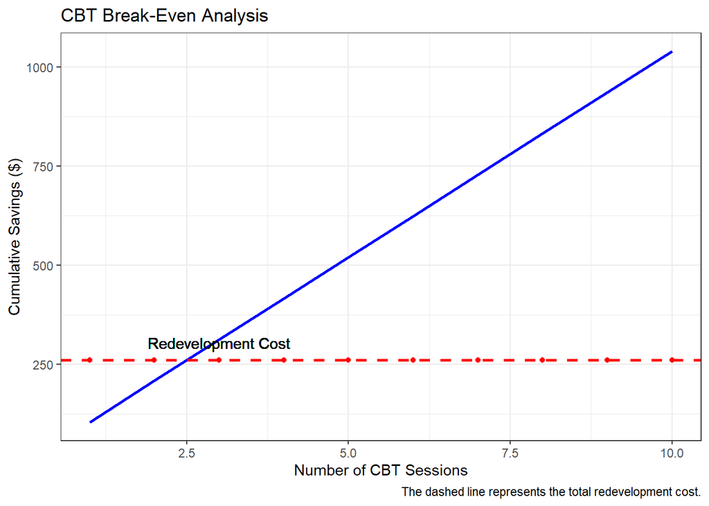

# 3. Impact on Learning Quality and Experience

Qualitative feedback will be gathered post-training via a survey to assess the impact on learning quality and experience. The survey will be administered to the participants of the CBTs and the results will be analyzed and a comparison analysis conducted with previous ILT-based survey data to determine the impact on learning quality and experience.